# Using `pool()` for multiple imputation in `mice` package

By Justin Bélair © | Biostatistician at JB Statistical Consulting

[Find the RMarkdown Notebook on Github and Run the Code Yourself!](https://github.com/JB-Statistical-Consulting/biostatistics/tree/main/biostatistics.ca)

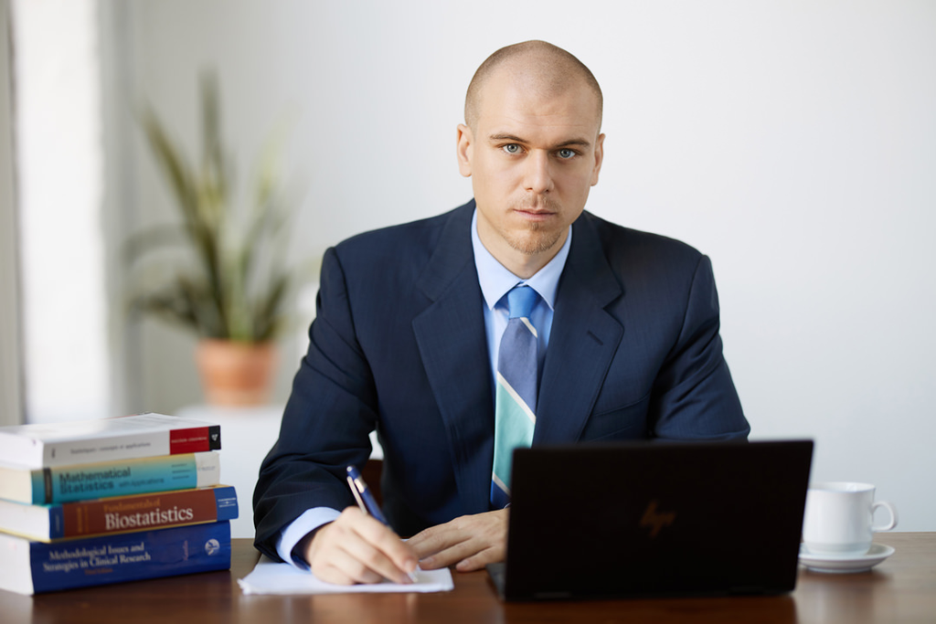

# Multiple Imputation

Multiple Imputation (MI) is the cutting-edge statistical approach to dealing with missing data. Unfortunately, many often forego this technique because it requires substantial statistical and programming knowledge.

We’ll show you that it need not be complicated for most of the analyses.

## Example

We load our data and see there are missing values.

```r
# We look at our data

data.analysis <- read.csv("toy_data_binary_outcome_w_miss.csv")

str(data.analysis)
```

```
## 'data.frame':    247 obs. of  7 variables:
##  $ X             : int  1 2 3 4 5 6 7 8 9 10 ...
##  $ ID            : int  10933 12450 8601 8627 20225 11704 8510 13272 22146 22266 ...
##  $ Binary_Outcome: int  1 1 1 1 0 1 0 0 0 0 ...
##  $ Age           : int  82 57 67 67 83 62 78 68 76 74 ...
##  $ Gender        : int  0 1 1 0 0 1 1 1 0 0 ...
##  $ Education     : int  12 14 14 18 20 21 18 20 19 18 ...
##  $ Exposure      : num  10.1 37.8 NA NA 28.6 ...
```

We are interested in estimating the effect of the Exposure on the **Binary_Outcome** variable, adjusted for **Age**, **Gender** and **Education**. We choose the logistic regression model.

```r
glm(Binary_Outcome ~ Exposure + Age + Gender + Education, data = data.analysis,
    family = binomial(link = "logit"))
```

```
##
## Call:  glm(formula = Binary_Outcome ~ Exposure + Age + Gender + Education,
##     family = binomial(link = "logit"), data = data.analysis)
##
## Coefficients:
## (Intercept)     Exposure          Age       Gender    Education
##    -1.03578      0.06322     -0.01913      0.08195      0.05197
##
## Degrees of Freedom: 150 Total (i.e. Null);  146 Residual
##   (96 observations deleted due to missingness)
## Null Deviance:       209.3
## Residual Deviance: 200   AIC: 210
```

Notice that `R` defaults to complete-case analysis, that is, any row with a missing value is removed. We see in the model output that 96 of the 247 observations were deleted due to missingness ($96/247 = 38.9\%$) - we cannot afford such loss of information. All the more considering that not all columns are missing from the deleted rows!

## Multiple imputation strategy :

```r
imp <- mice(data.analysis, m = 5, print = FALSE)

logistic.regression <- with(imp,
                            glm(Binary_Outcome ~ Exposure + Age + Gender + Education, data = data.analysis, family = binomial(link = "logit"))
                            )

summary(pool(logistic.regression))
```

```
##          term    estimate  std.error  statistic       df   p.value
## 1 (Intercept) -1.03577972 1.97196260 -0.5252532 144.0258 0.6002148
## 2    Exposure  0.06321821 0.02429826  2.6017587 144.0258 0.0102435
## 3         Age -0.01912862 0.02059962 -0.9285907 144.0258 0.3546549
## 4      Gender  0.08195242 0.34474032  0.2377222 144.0258 0.8124344
## 5   Education  0.05197116 0.06508698  0.7984878 144.0258 0.4259022
```

[^1]: See [van Buuren, Flexible Imputation of Missing Data](https://stefvanbuuren.name/fimd/) for more information